# Analysis on the relation between quantity of apprehended falsified bills and population in Brazil

By: Rafael Neves

## Summary

The goal of this paper is to verify if there is any relation between the population and the quantity of apprehended fake bills for Brazilian states in the time period between the years of $2001$ and $2021$. The data set for the population of the states is from Brazilian Institute of Geography and Statistics (IBGE) e the data set on the apprehended falsified bills is from Central Bank of Brazil (BCB).

## Explaining the data sets

The data set for the fake bills is composed of $5$ variables. Of those, two are qualitative, State and Type. The State variable is the Brazilian Federative Unit (UF) where the bills were found. The Type variable describes which family of bills the apprehended bills came from. This variable can only obtain three values: Cedulas - 1a. familia, Cedulas - 2a. familia and Cedulas - em polimero. These three classifications just describe the making of the bills. The 1a. familia bills are the original real bills from the Plano Real in $1994$. They stopped being produced in $2010$ and where substituted by the 2a. familia bills, but are still in circulation, although it’s rare to see them in the day to day. Finally the Cedulas - em polimero was a “celebratory” $10$ reais bill for the $500$ years of the arrival of the Portuguese on Brazilian soil that were only produced once in the year $2000$. In recent years most bills in circulation are from the 2a. familia. An image of the different bills can be seen bellow. The ones to the left are from the 1a familia and the ones to the right are from the 2a familia. The one on the bottom left with a red dot is the cedula em polimero.

[figure not shown]

[figure not shown]

In this paper the differences between the types will be ignored since the emphasis is on population. However it must be acknowledged that the different bills have different mechanisms of identification making some harder to falsify than others. Which may influence the results. For this it will be assumed that the distribution of the types is uniform among all bills, minimizing the effects from the different types of bills.  
As for the 3 quantitative variables. The first one is years, which will be limited to time period between $2001$ and $2021$. The second quantitative variable is value. Value is the monetary value of each bill apprehended, it can have the following values $1,2,5,10,20,50,100,200$. However, the $1$ real bill stopped being produced in $2005$, the $20$ reais bill started production in $2002$ and the $200$ reais bill only was produced in $2020$. These changes in the production of certain bills could lead to some noise in the data. However it will also be assumed that these changes will uniformly distributed among all bills. The last variable for this data set is Quantity. This represents the quantity of apprehended bills, these values range from $0$ to $188792$.

The data set for the population of the states has $29$ quantitative variables, one of which represents the years between $2001$ and $2021$. Another represents the total population for each year and the rest represent the populations for each UF for each year.

## Analysis

The main variable that will be analysed is the Quantity variable from the fake bills data set. The values for this variable have an average of $1933.1$ with a standard deviation of $7253.51$ for the $5248$ observations reported between years of $2001$ and $2021$.  
Now looking exclusively at the quantity for the bills apprehended in the state of São Paulo, the average becomes $16028.8$, with a standard deviation of $27731.69$ for the $220$ observations reported between years of $2001$ and $2021$. This is interesting since on average the population of São Paulo for this time period is $42529551$, with a standard deviation of $2852649.86$, which represents about $21.78\%$ of the average population of Brazil. This is a first indication of a relation between population and quantity of apprehended bills.

The following histogram shows the quantities of apprehended bills between the years of $2001$ and $2021$ for the entire country.

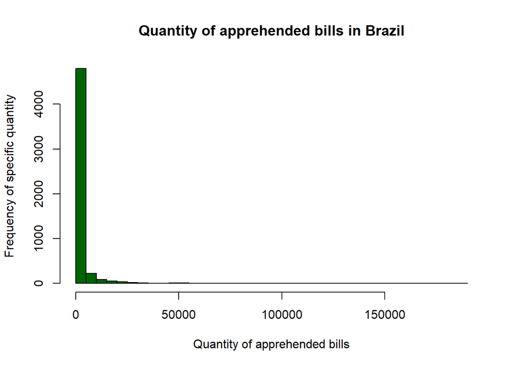

However, since $25.59\%$ of the quantity of apprehended bills is for quantities less than $20$ bills and $33.75\%$ of the quantity of apprehended bills is for quantities larger than $500$. Thus, a histogram bounded by quantities larger than $20$ and less then $500$ and with the probability of each specific quantity instead of frequency, can show a different perspective on the values of apprehended bills.

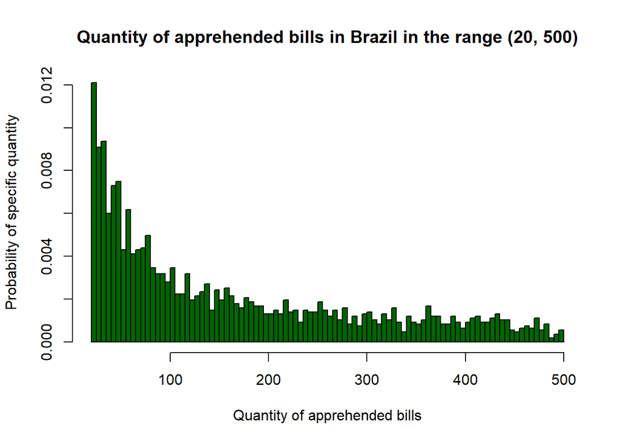

For this smaller sample the histogram is still right-skewed. Which indicates that, even if considering that smaller apprehended quantities tend to happen due to just random chance, most apprehensions are more likely to be from individual bills being collected over the year rather than single large scale operations.

$$H_0: \mu_{2006}-\mu_{2007} = 0$$
$$H_1: \mu_{2006}-\mu_{2007} > 0$$
$$P\left(\frac{\overline{X_{2006}}-\overline{X_{2007}}-(\mu_{2006}-\mu_{2007})}{\sqrt{\frac{\sigma^2_{2006}}{n_{2006}}+\frac{\sigma^2_{2007}}{n_{2007}}}}\leq\frac{33231.25-33252.75-0} {\sqrt{\frac{65229.9550749^2}{8}+\frac{61753.6470033^2}{8}}}\right)$$

Calculating the hypothesis, results in a $p-value$ of $0.4997394$, indicating that the year of $2006$ is not likely to be an abnormality for São Paulo.

It could also be the case that both years are outliers for the values São Paulo. To verify if this is the case a hypothsis test with a level of significance of $\alpha = 0.05$ will be performed. Let the null hypothesis be that the average quantity of bills apprehended between the years of $2001$ and $2021$ is the same as the average quantity of bills apprehended in the year $2006$. Let the alternative hypothesis be that it is actually less than the average quantity apprehended in $2006$.

$$H_0: \mu_{avg} = \mu_{2006}$$
$$H_1: \mu_{avg}<\mu_{2006}$$
$$P\left(\frac{\overline{X_{avg}}-\overline{X_{2006}}}{\sqrt{\frac{\sigma^2_{avg}}{n_{avg}}}}\leq\frac{16028.8-33231.25} {\sqrt{\frac{27731.6916486^2}{220}}}\right)$$

Performing the hypothesis test results in a $p-value$ of $1.776581* 10^{-20} < \alpha = 0.05$. Therefore, it rejects the null hypothesis and shows that the years $2006$ and $2007$ are very likely to be outliers.

Analizing the data from the most populous UF, São Paulo, leads to the conclusion that the years of $2006$ and $2007$ are outliers from the data. However, every UF is likely to have outliers in their quantities. The best way to minimize the influence of such, is to use the maximum amount of data and analyze the entire time period.  
The following scatter-plot has the average population on the x-axis and the average quantity on the y-axis. It represents the averages for the years $2001$ through $2021$.

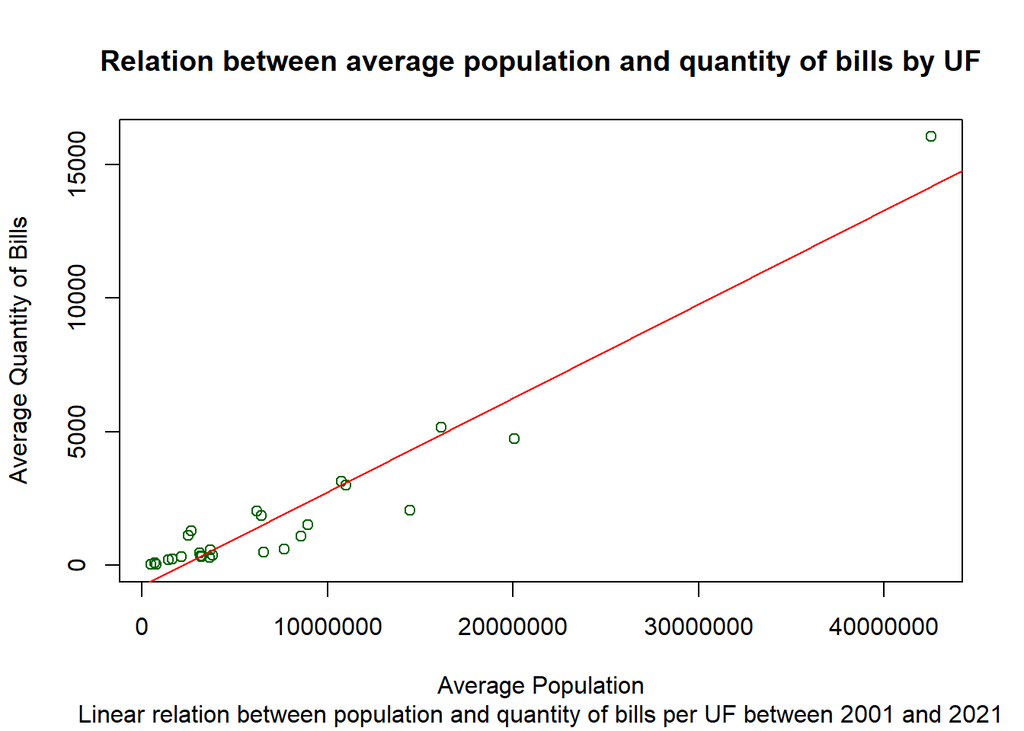

Notice the positive linear relation between population and quantity of bills. This shows that the initial assumption that population and quantity of apprehended bills are related was correct.  
This relation can be explained by the fact the the more people a UF has, the greater the amount of bills in that UF. If the probability of any given bill being fake bill is the same for all bills, it would explain the relation between population and falsified bills.  
However, it could also be the case that the quantity of falsified bills is related to crime rates. Which are then related to population. This hypothesis escapes the goals of this analysis, but let it be an indication for future research topics.  
In conclusion, there seems to be a relation between population and quantity of apprehended bills. However a broader analysis is needed, since there could be to other factors that influence the quantity of apprehended bills.

## References

Banco Central do Brasil, . (2015). Cédulas do real. Banco Central do brasil. Retrieved November 23, 2021, from https://www.bcb.gov.br/cedulasemoedas/cedulas.  
Banco Central do Brasil, . (2015). Cédulas do real. Retrieved 2021, from https://www.bcb.gov.br/content/cedulasemoedas/PublishingImages/indexcedulas/notassegundafamilia.PNG.  
Banco Central do Brasil, . (2021). Falsificações por ano e Por Estado. Portal Brasileiro de Dados Abertos. Retrieved November 12, 2021, from https://dados.gov.br/dataset/falsificacoes-por-ano-e-por-estado.  
IBGE, . (2021). População residente estimada. Tabela 6579: População Residente Estimada. Retrieved November 21, 2021, from https://sidra.ibge.gov.br/tabela/6579.  
Wikepedia, . (2021). Hyperinflation in Brazil. Retrieved 2021, from https://i1.wp.com/radames.manosso.nom.br/palavras/files/2019/10/real-1a-familia.jpg?resize=474%2C881.